# Dyadic data analysis with **amen**

## Social Relations Model

A running example in this section will be an analysis of international trade data, where yi,j is the (log) dollar-value of exports from country i to country j. These data can be obtained from the IR90s dataset included in the amen package. Specifically, we will analyze trade data between the 30 countries having the highest GDPs:

```r
library(amen)
data(IR90s)
gdp<-IR90s$nodevars[,2]
topgdp<-which(gdp>=sort(gdp,decreasing=TRUE)[30] )
Y<-log( IR90s$dyadvars[topgdp,topgdp,2] + 1 )
```

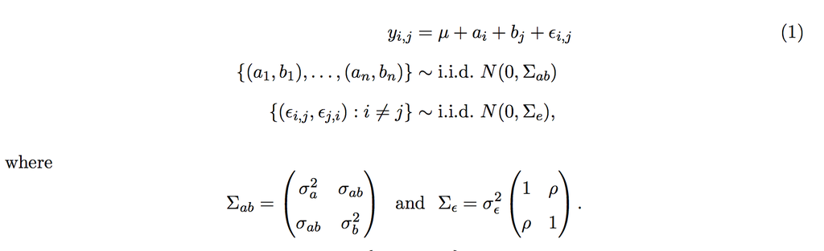

Social Relations Model formula

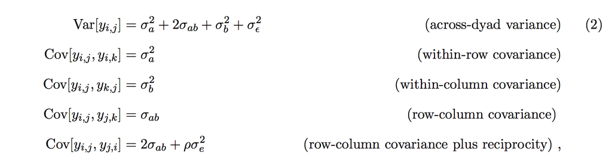

Social Relations Model Variance

The `amen` package provides model fitting and evaluation tools for the SRM via the default values of the `ame` command:

```r
fit_SRM<-ame(Y,plot=F)
```

Get the posterior mean:

```r
mean(fit_SRM$BETA)
```

```
## [1] 0.6616995
```

```r
apply(fit_SRM$VC[,1:3],2,mean)# model-based estimate
```

```
##        va       cab        vb
## 0.2809375 0.2364107 0.2722367
```

```r
mean(fit_SRM$VC[,4]) # model-based estimate
```

```
## [1] 0.8577201
```

## Social relations regression modeling

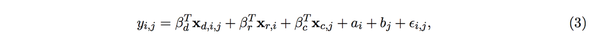

Social Relations Regression Model

We illustrate parameter estimation for the SRRM by fitting the model to the trade data. Nodal covariates include (log) population, (log) GDP, and polity, a measure of democracy. Dyadic covariates include the number the number of conflicts, (log) geographic distance between countries, the number of shared IGO memberships, and a polity interaction (the product of the nodal polity scores).

```r
dimnames(IR90s$nodevars)[[2]]
```

```
## [1] "pop"    "gdp"    "polity"
```

```r
Xn<-IR90s$nodevars[topgdp,]
Xn[,1:2]<-log(Xn[,1:2])
dimnames(IR90s$dyadvars)[[3]]
```

```
## [1] "conflicts"   "exports"     "distance"    "shared_igos" "polity_int"
```

```r
Xd<-IR90s$dyadvars[topgdp,topgdp,c(1,3,4,5)]
Xd[,,3]<-log(Xd[,,3])
```

The SRRM can be fit by specifying the covariates in the `ame` function:

```r
fit_srrm<-ame(Y,Xd=Xd,Xr=Xn,Xc=Xn,plot=F)
```

Posterior mean estimates, standard deviations, nominal z-scores and p-values may be obtained with the `summary` command:

```r
summary(fit_srrm)
```

```
##
## Regression coefficients:
##                   pmean   psd z-stat p-val
## intercept        -6.411 1.258 -5.096 0.000
## pop.row          -0.330 0.132 -2.498 0.012
## gdp.row           0.567 0.151  3.756 0.000
## polity.row       -0.015 0.020 -0.786 0.432
## pop.col          -0.302 0.127 -2.384 0.017
## gdp.col           0.537 0.148  3.635 0.000
## polity.col       -0.006 0.019 -0.309 0.757
## conflicts.dyad    0.076 0.042  1.823 0.068
## distance.dyad    -0.041 0.007 -6.087 0.000
## shared_igos.dyad  0.886 0.187  4.737 0.000
## polity_int.dyad  -0.001 0.001 -1.672 0.095
##
## Variance parameters:
##     pmean   psd
## va  0.265 0.105
## cab 0.214 0.098
## vb  0.251 0.099
## rho 0.785 0.020
## ve  0.157 0.011
```

It is instructive to compare these results to those that would be obtained under an ordinary linear regression model that assumes i.i.d. residual standard error. Such a model can be fit in the amen package by opting to fit a model with no row variance, column variance or dyadic correlation:

```r
fit_rm<-ame(Y,Xd=Xd,Xr=Xn,Xc=Xn,rvar=FALSE,cvar=FALSE,dcor=FALSE,plot=F)
```

```r
summary(fit_rm)
```

```
##
## Regression coefficients:
##                   pmean   psd  z-stat p-val
## intercept        -4.417 0.170 -25.947 0.000
## pop.row          -0.318 0.022 -14.621 0.000
## gdp.row           0.664 0.024  27.417 0.000
## polity.row       -0.007 0.005  -1.335 0.182
## pop.col          -0.280 0.023 -12.328 0.000
## gdp.col           0.622 0.024  25.590 0.000
## polity.col        0.002 0.005   0.509 0.611
## conflicts.dyad    0.238 0.057   4.152 0.000
## distance.dyad    -0.053 0.004 -14.407 0.000
## shared_igos.dyad -0.021 0.028  -0.739 0.460
## polity_int.dyad   0.000 0.001   0.280 0.780
##
## Variance parameters:
##     pmean   psd
## va  0.000 0.000
## cab 0.000 0.000
## vb  0.000 0.000
## rho 0.000 0.000
## ve  0.229 0.011
```

## Transitivity and stochastic equivalence via multiplicative effects

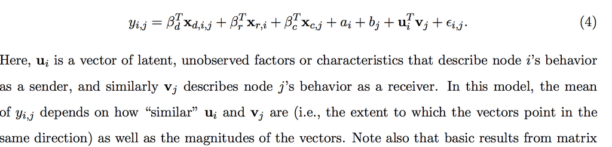

```r
fit_ame2<-ame(Y,Xd,Xn,Xn,R=2,plot=F)
```

```r
summary(fit_ame2)
```

```
##
## Regression coefficients:
##                   pmean   psd z-stat p-val
## intercept        -4.096 0.777 -5.270 0.000
## pop.row          -0.281 0.069 -4.081 0.000
## gdp.row           0.567 0.092  6.187 0.000
## polity.row       -0.001 0.010 -0.064 0.949
## pop.col          -0.236 0.072 -3.290 0.001
## gdp.col           0.521 0.100  5.208 0.000
## polity.col        0.008 0.010  0.761 0.447
## conflicts.dyad    0.016 0.037  0.420 0.674
## distance.dyad    -0.038 0.004 -9.542 0.000
## shared_igos.dyad  0.095 0.074  1.281 0.200
## polity_int.dyad  -0.001 0.000 -2.273 0.023
##
## Variance parameters:
##     pmean   psd
## va  0.074 0.023
## cab 0.030 0.017
## vb  0.072 0.022
## rho 0.620 0.037
## ve  0.064 0.004
```

## AME models for binary data

For example, the `amen` dataset `lazegalaw` includes a social network of friendship ties between 71 members of a law firm, along with data on two other dyadic variables and several nodal variables. The friendship data are displayed as a graph in Figure 8, where the nodes are colored according to each lawyer’s office location.

```r
data(lazegalaw)
Y<-lazegalaw$Y[,,2]
Xd<-lazegalaw$Y[,,-2]
Xn<-lazegalaw$X
dimnames(Xd)[[3]]
```

```
## [1] "advice" "cowork"
```

```r
dimnames(Xn)[[2]]
```

```
## [1] "status"    "female"    "office"    "seniority" "age"       "practice"
## [7] "school"
```

[output not shown]

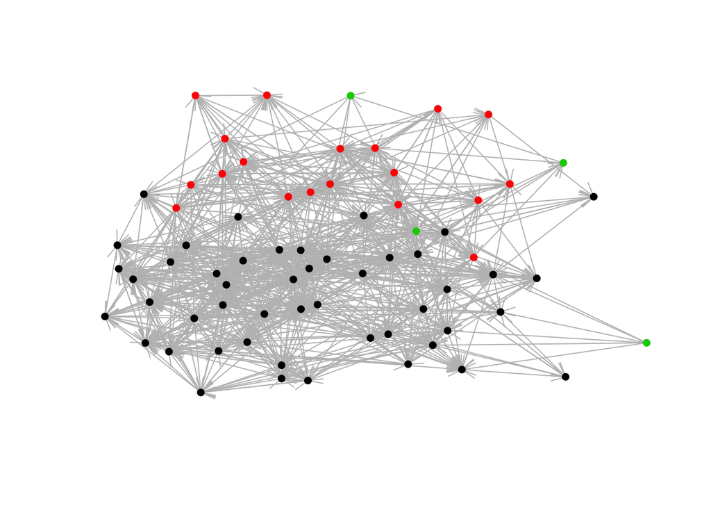

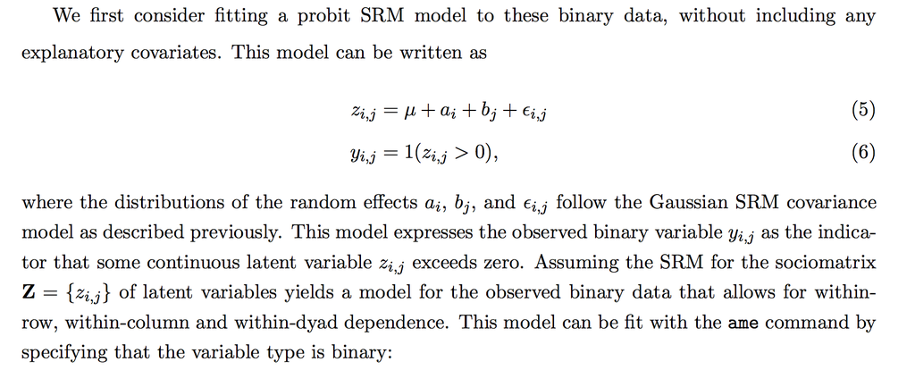

Binary Model

```r
netplot(lazegalaw$Y[,,2],ncol=Xn[,3])
```

```r
fit_SRM<-ame(Y,model="bin",plot=F)
```

```r
summary(fit_SRM)
```

```
##
## Regression coefficients:
##           pmean   psd  z-stat p-val
## intercept -1.07 0.081 -13.145     0
##
## Variance parameters:
##     pmean   psd
## va  0.179 0.038
## cab 0.041 0.026
## vb  0.159 0.035
## rho 0.303 0.045
## ve  1.000 0.000
```

We next consider a probit SRRM that includes the SRM terms and linear regression effects for some nodal and dyadic covariates.

```r
Xno<-Xn[,c(1,2,4,5,6)]
fit_SRRM<-ame(Y, Xd=Xd, Xr=Xno, Xc=Xno, model="bin",plot=F)
```

```r
summary(fit_SRRM)
```

```
##
## Regression coefficients:
##                pmean   psd z-stat p-val
## intercept      0.880 0.658  1.338 0.181
## status.row    -0.174 0.175 -0.993 0.321
## female.row     0.007 0.143  0.051 0.960
## seniority.row -0.008 0.012 -0.681 0.496
## age.row       -0.016 0.009 -1.725 0.085
## practice.row  -0.227 0.109 -2.092 0.036
## status.col    -0.167 0.145 -1.149 0.251
## female.col    -0.027 0.123 -0.219 0.827
## seniority.col  0.012 0.011  1.059 0.290
## age.col       -0.008 0.008 -1.066 0.287
## practice.col  -0.285 0.110 -2.598 0.009
## advice.dyad   -0.080 0.075 -1.067 0.286
## cowork.dyad    1.281 0.063 20.310 0.000
##
## Variance parameters:
##     pmean   psd
## va  0.170 0.037
## cab 0.012 0.025
## vb  0.134 0.032
## rho 0.110 0.048
## ve  1.000 0.000
```

For a model with a rank-3 multiplicative effect:

```r
fit_AME<-ame(Y, Xd=Xd[,,2], R=3, model="bin",plot=F)
```

```r
U<-fit_AME$U
V<-fit_AME$V
round(cor(U, Xno),2)
```

```
##      status female seniority   age practice
## [1,]  -0.12  -0.02     -0.20 -0.25     0.00
## [2,]  -0.34  -0.04      0.24  0.26     0.62
## [3,]  -0.03   0.28     -0.01  0.12     0.20
```

```r
round(cor(V, Xno),2)
```

```
##      status female seniority  age practice
## [1,]  -0.81  -0.32      0.71 0.62     0.24
## [2,]  -0.04   0.15     -0.06 0.00     0.55
## [3,]  -0.06   0.14      0.26 0.31     0.19
```